# Bike_Sharing

Charlene

2023-08-11

## Import CSV files

2019 Q1 - 2019 Q4

```r
library(readr)
library(here)
Q1_2019 <- read.csv(here("data","Divvy_Trips_2019_Q1.csv.gz"))
Q2_2019 <- read.csv(here("data","Divvy_Trips_2019_Q2.csv.gz"))
Q3_2019 <- read.csv(here("data","Divvy_Trips_2019_Q3.csv.gz"))
Q4_2019 <- read.csv(here("data","Divvy_Trips_2019_Q4.csv.gz"))
```

NOTE: Dataset is too large therefore uploading a compressed file ## Preview data

```r
print("column names Q1")
```

```
## [1] "column names Q1"
```

```r
colnames(Q1_2019)
```

```
##  [1] "trip_id"           "start_time"        "end_time"
##  [4] "bikeid"            "tripduration"      "from_station_id"
##  [7] "from_station_name" "to_station_id"     "to_station_name"
## [10] "usertype"          "gender"            "birthyear"
```

```r
print("column names Q2")
```

```
## [1] "column names Q2"
```

```r
colnames(Q2_2019)
```

```
##  [1] "X01...Rental.Details.Rental.ID"
##  [2] "X01...Rental.Details.Local.Start.Time"
##  [3] "X01...Rental.Details.Local.End.Time"
##  [4] "X01...Rental.Details.Bike.ID"
##  [5] "X01...Rental.Details.Duration.In.Seconds.Uncapped"
##  [6] "X03...Rental.Start.Station.ID"
##  [7] "X03...Rental.Start.Station.Name"
##  [8] "X02...Rental.End.Station.ID"
##  [9] "X02...Rental.End.Station.Name"
## [10] "User.Type"
## [11] "Member.Gender"
## [12] "X05...Member.Details.Member.Birthday.Year"
```

```r
print("column names Q3")
```

```
## [1] "column names Q3"
```

```r
colnames(Q3_2019)
```

```
##  [1] "trip_id"           "start_time"        "end_time"
##  [4] "bikeid"            "tripduration"      "from_station_id"
##  [7] "from_station_name" "to_station_id"     "to_station_name"
## [10] "usertype"          "gender"            "birthyear"
```

```r
print("column names Q4")
```

```
## [1] "column names Q4"
```

```r
colnames(Q4_2019)
```

```
##  [1] "trip_id"           "start_time"        "end_time"
##  [4] "bikeid"            "tripduration"      "from_station_id"
##  [7] "from_station_name" "to_station_id"     "to_station_name"
## [10] "usertype"          "gender"            "birthyear"
```

## Standardise column name of Q2_2019

Q2 has different column names compared to the rest, so we have to fix that.

```r
library(dplyr)
Q2_2019 <- Q2_2019 %>%
  rename(trip_id = X01...Rental.Details.Rental.ID,
         start_time = X01...Rental.Details.Local.Start.Time,
         end_time = X01...Rental.Details.Local.End.Time,
         bikeid = X01...Rental.Details.Bike.ID,
         tripduration = X01...Rental.Details.Duration.In.Seconds.Uncapped,
         from_station_id = X03...Rental.Start.Station.ID,
         from_station_name =X03...Rental.Start.Station.Name,
         to_station_id = X02...Rental.End.Station.ID,
         to_station_name = X02...Rental.End.Station.Name,
         usertype = User.Type,
         gender = Member.Gender,
         birthyear = X05...Member.Details.Member.Birthday.Year)
```

## Combining all the 4 quaters to a full year data

```r
data_2019 <- rbind(Q1_2019, Q2_2019, Q3_2019, Q4_2019)
```

## Data Cleaning & Transformation

In order to proceed with our analysis, we need to have two additional information: 1. Ride Duration (end time - start time) 2. Day of week of bike rental

Getting ride duration for each trip:

```r
# check if there is any rows with start_time later than end_time:
sum(data_2019$start_time > data_2019$end_time) # 13 rows affected
```

```
## [1] 13
```

```r
which(data_2019$start_time > data_2019$end_time) #identify which rows affected
```

```
##  [1] 3498429 3498434 3498436 3498437 3498438 3498440 3498441 3498442 3498443
## [10] 3498444 3498446 3498447 3498448
```

```r
#change data type to dttm format + create start and end column that satisfy condition start is earlier than end.
library(dplyr)
library(lubridate)
data_2019<- data_2019 %>%
  mutate(start = if_else(as_datetime(start_time) > as_datetime(end_time), as_datetime(end_time), as_datetime(start_time)), end = if_else(as_datetime(start_time) > as_datetime(end_time), as_datetime(start_time), as_datetime(end_time)))

# double check if any start is later than end
sum(data_2019$start > data_2019$end)
```

```
## [1] 0
```

Create a new column to show ride duration:

```r
data_2019 <- data_2019 %>%
  mutate(ride_duration = end - start)
```

Create a new column to show day of week of bike rental

```r
data_2019$day = strftime(data_2019$start_time,'%a') #%A means full weekday name
```

## Descriptive Analysis

Average, min and max ride duration (mins):

```r
data_2019 %>%
  group_by(usertype) %>%
  summarise(mean(ride_duration),max(ride_duration),min(ride_duration))
```

```
## # A tibble: 2 × 4
##   usertype   `mean(ride_duration)` `max(ride_duration)` `min(ride_duration)`
##   <chr>      <drtn>                <drtn>               <drtn>
## 1 Customer   57.01793 mins         177200.4 mins        1.016667 mins
## 2 Subscriber 14.32788 mins         150943.9 mins        1.016667 mins
```

Total number of trips made by Customer VS Subscriber:

```r
data_2019 %>%
  group_by(usertype) %>%
  summarise(Number_customer= sum(usertype == "Customer"),
            Number_subscriber = sum(usertype == "Subscriber"))
```

```
## # A tibble: 2 × 3
##   usertype   Number_customer Number_subscriber
##   <chr>                <int>             <int>
## 1 Customer            880637                 0
## 2 Subscriber               0           2937367
```

Number of trips made by Customer VS Subscriber in each day of the week:

```r
data_2019 %>%
  group_by(usertype,day) %>%
  summarise(n_distinct(trip_id)) %>%
  arrange(day)
```

```
## # A tibble: 14 × 3
## # Groups:   usertype [2]
##    usertype   day   `n_distinct(trip_id)`
##    <chr>      <chr>                 <int>
##  1 Customer   Fri                  121141
##  2 Subscriber Fri                  456966
##  3 Customer   Mon                  101489
##  4 Subscriber Mon                  458780
##  5 Customer   Sat                  208056
##  6 Subscriber Sat                  287163
##  7 Customer   Sun                  170179
##  8 Subscriber Sun                  256241
##  9 Customer   Thu                  101372
## 10 Subscriber Thu                  486915
## 11 Customer   Tue                   88655
## 12 Subscriber Tue                  497025
## 13 Customer   Wed                   89745
## 14 Subscriber Wed                  494277
```

Average ride duration each day of the week Customer VS Subscriber:

```r
data_2019 %>%
  group_by(usertype,day) %>%
  summarise(mean(ride_duration)) %>%
  arrange(day)
```

```
## # A tibble: 14 × 3
## # Groups:   usertype [2]
##    usertype   day   `mean(ride_duration)`
##    <chr>      <chr> <drtn>
##  1 Customer   Fri   60.17561 mins
##  2 Subscriber Fri   13.89748 mins
##  3 Customer   Mon   54.49989 mins
##  4 Subscriber Mon   14.24928 mins
##  5 Customer   Sat   54.06111 mins
##  6 Subscriber Sat   16.30271 mins
##  7 Customer   Sun   56.18474 mins
##  8 Subscriber Sun   15.40377 mins
##  9 Customer   Thu   59.95112 mins
## 10 Subscriber Thu   13.77979 mins
## 11 Customer   Tue   57.41328 mins
## 12 Subscriber Tue   14.15259 mins
## 13 Customer   Wed   60.33407 mins
## 14 Subscriber Wed   13.80984 mins
```

## Data Viz

Bike usage trend over the week

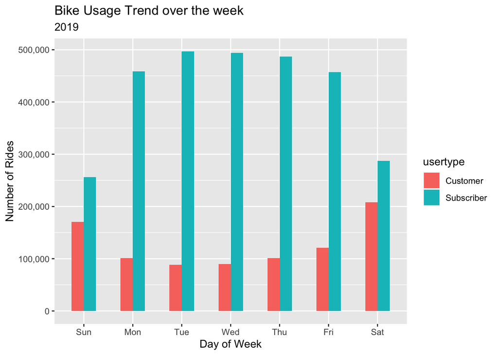

```r
library(ggplot2)
days_of_the_week <- c("Sun", "Mon", "Tue","Wed","Thu","Fri","Sat")

ggplot(data = data_2019) +
  geom_bar(mapping=aes(x= factor (day,days_of_the_week),fill= usertype), width=.5, position = "dodge")+ labs(title="Bike Usage Trend over the week", x= "Day of Week", y= "Number of Rides", subtitle = "2019") + scale_y_continuous(labels = scales::comma)
```

Avg bike rental duration trend over the week

```
## Defaulting to continuous.
```

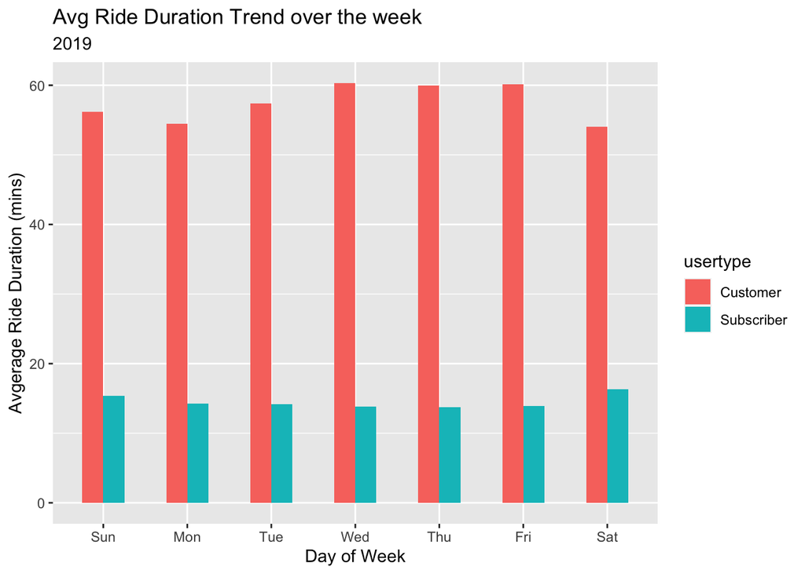

```r
data_2019 %>%
  group_by(usertype,day) %>%
  summarise(avg_duration = mean(ride_duration)) %>%
  arrange(day) %>%
  ggplot(aes(x= factor(day,days_of_the_week),y=avg_duration,fill= usertype)) +
  geom_bar(width=.5, position = "dodge", stat="identity")+ labs(title="Avg Ride Duration Trend over the week", x= "Day of Week", y= "Avgerage Ride Duration (mins)", subtitle = "2019")
```

## Recommendation

To increase revenue of the bike rental service, management can look into ways to attract new customers by having promotional bundle for longer trips such as: 1. Full day ride pass on weekends for a fixed price. 2. Half day ride pass for a fixed price.

Additional promotions for weekday bundle to attract more customers to use the rental service on weekdays: 1. Ride for 40 mins and get an additional 20 mins for free

Since most subscribers uses the bike rental for short trips (< 20 mins), they are most likely using it as a mode of transport to get from one place to another (eg: work to office). Management can come up with promotional bundles for peak hours such as: lunch hour, morning & evening rush hour when people are commuting to/from work. This will help to give more incentives for users to subscribe and be a member of the bike rental.